# Kaggle

Gaurav Bansal

Saturday, August 23, 2014

## Data Fields

datetime - hourly date + timestamp  
season - 1 = spring, 2 = summer, 3 = fall, 4 = winter holiday - whether the day is considered a holiday workingday - whether the day is neither a weekend nor holiday weather - 1: Clear, Few clouds, Partly cloudy, Partly cloudy 2: Mist + Cloudy, Mist + Broken clouds, Mist + Few clouds, Mist 3: Light Snow, Light Rain + Thunderstorm + Scattered clouds, Light Rain + Scattered clouds 4: Heavy Rain + Ice Pallets + Thunderstorm + Mist, Snow + Fog temp - temperature in Celsius atemp - “feels like” temperature in Celsius humidity - relative humidity windspeed - wind speed casual - number of non-registered user rentals initiated registered - number of registered user rentals initiated count - number of total rentals

```r
bikejan <- read.csv("bikejan.csv")
bikejan$datetime <- as.POSIXlt(as.character(bikejan$datetime))
str(bikejan)
```

```
## 'data.frame':    456 obs. of  18 variables:
##  $ datetime  : POSIXlt, format: "0001-01-11 00:00:00" "0001-01-11 01:00:00" ...
##  $ season    : int  1 1 1 1 1 1 1 1 1 1 ...
##  $ holiday   : int  0 0 0 0 0 0 0 0 0 0 ...
##  $ workingday: int  0 0 0 0 0 0 0 0 0 0 ...
##  $ weather   : int  1 1 1 1 1 2 1 1 1 1 ...
##  $ temp      : num  9.84 9.02 9.02 9.84 9.84 ...
##  $ atemp     : num  14.4 13.6 13.6 14.4 14.4 ...
##  $ humidity  : num  81 80 80 75 75 75 80 86 75 76 ...
##  $ windspeed : num  0 0 0 0 0 ...
##  $ casual    : int  3 8 5 3 0 0 2 1 1 8 ...
##  $ registered: int  13 32 27 10 1 1 0 2 7 6 ...
##  $ count     : int  16 40 32 13 1 1 2 3 8 14 ...
##  $ year      : int  2011 2011 2011 2011 2011 2011 2011 2011 2011 2011 ...
##  $ month     : int  1 1 1 1 1 1 1 1 1 1 ...
##  $ date      : int  1 1 1 1 1 1 1 1 1 1 ...
##  $ hour      : int  0 1 2 3 4 5 6 7 8 9 ...
##  $ day       : int  7 7 7 7 7 7 7 7 7 7 ...
##  $ flag      : int  1 1 1 1 1 1 1 1 1 1 ...
```

```r
summary(bikejan)
```

```
##     datetime                       season     holiday
##  Min.   :0001-01-11 00:00:00   Min.   :1   Min.   :0.0000
##  1st Qu.:0001-05-11 17:45:00   1st Qu.:1   1st Qu.:0.0000
##  Median :0001-10-11 11:30:00   Median :1   Median :0.0000
##  Mean   :0006-11-05 00:07:54   Mean   :1   Mean   :0.0526
##  3rd Qu.:0015-01-11 05:15:00   3rd Qu.:1   3rd Qu.:0.0000
##  Max.   :0019-01-11 23:00:00   Max.   :1   Max.   :1.0000
##
##    workingday       weather          temp           atemp
##  Min.   :0.000   Min.   :1.00   Min.   : 3.28   Min.   : 3.03
##  1st Qu.:0.000   1st Qu.:1.00   1st Qu.: 6.56   1st Qu.: 7.96
##  Median :1.000   Median :1.00   Median : 8.20   Median : 9.85
##  Mean   :0.632   Mean   :1.47   Mean   : 8.57   Mean   :10.66
##  3rd Qu.:1.000   3rd Qu.:2.00   3rd Qu.: 9.84   3rd Qu.:12.88
##  Max.   :1.000   Max.   :3.00   Max.   :18.86   Max.   :22.73
##
##     humidity       windspeed        casual        registered
##  Min.   : 28.0   Min.   : 0.0   Min.   : 0.00   Min.   :  0
##  1st Qu.: 44.0   1st Qu.: 9.0   1st Qu.: 0.00   1st Qu.: 13
##  Median : 53.0   Median :13.0   Median : 2.00   Median : 43
##  Mean   : 57.4   Mean   :13.9   Mean   : 4.66   Mean   : 50
##  3rd Qu.: 69.0   3rd Qu.:19.0   3rd Qu.: 6.00   3rd Qu.: 70
##  Max.   :100.0   Max.   :39.0   Max.   :47.00   Max.   :216
##                                 NA's   :25      NA's   :25
##      count            year          month        date         hour
##  Min.   :  1.0   Min.   :2011   Min.   :1   Min.   : 1   Min.   : 0.00
##  1st Qu.: 12.0   1st Qu.:2011   1st Qu.:1   1st Qu.: 5   1st Qu.: 5.75
##  Median : 44.0   Median :2011   Median :1   Median :10   Median :11.50
##  Mean   : 52.7   Mean   :2011   Mean   :1   Mean   :10   Mean   :11.50
##  3rd Qu.: 77.2   3rd Qu.:2011   3rd Qu.:1   3rd Qu.:15   3rd Qu.:17.25
##  Max.   :219.0   Max.   :2011   Max.   :1   Max.   :19   Max.   :23.00
##
##       day            flag
##  Min.   :1.00   Min.   :-23
##  1st Qu.:3.00   1st Qu.:  1
##  Median :4.00   Median :  1
##  Mean   :4.21   Mean   :  0
##  3rd Qu.:6.00   3rd Qu.:  1
##  Max.   :7.00   Max.   :  1
##
```

```r
x <- 1:10
y <- 990:999
```

## Univariate Analysis of Categorical Variables

1. Season

```r
table(bikejan$season)/24
```

```
##
##  1
## 19
```

2. Holiday

```r
table(bikejan$holiday)/24
```

```
##
##  0  1
## 18  1
```

```r
bikejan[(bikejan$holiday==1),c(15,17)]
```

```
##     date day
## 385   17   2
## 386   17   2
## 387   17   2
## 388   17   2
## 389   17   2
## 390   17   2
## 391   17   2
## 392   17   2
## 393   17   2
## 394   17   2
## 395   17   2
## 396   17   2
## 397   17   2
## 398   17   2
## 399   17   2
## 400   17   2
## 401   17   2
## 402   17   2
## 403   17   2
## 404   17   2
## 405   17   2
## 406   17   2
## 407   17   2
## 408   17   2
```

3. Working Day

```r
table(bikejan$workingday)/24
```

```
##
##  0  1
##  7 12
```

```r
table(bikejan$day)/24
```

```
##
## 1 2 3 4 5 6 7
## 2 2 4 2 3 3 3
```

4. Weather

```r
table(bikejan$weather)/24
```

```
##
##      1      2      3
## 11.458  6.167  1.375
```

```r
table(bikejan$weather)
```

```
##
##   1   2   3
## 275 148  33
```

## Univariate Analysis for continuous variables

1. temp

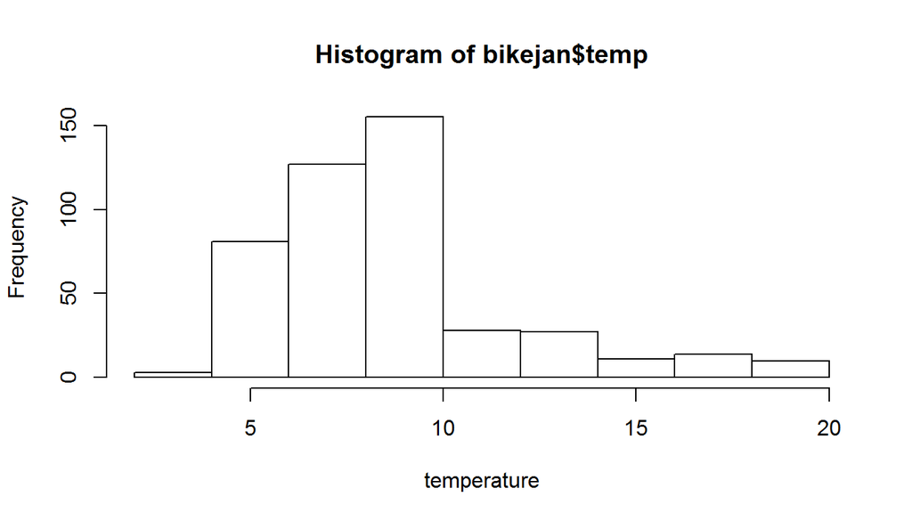

```r
hist(bikejan$temp,xlab="temperature")
```

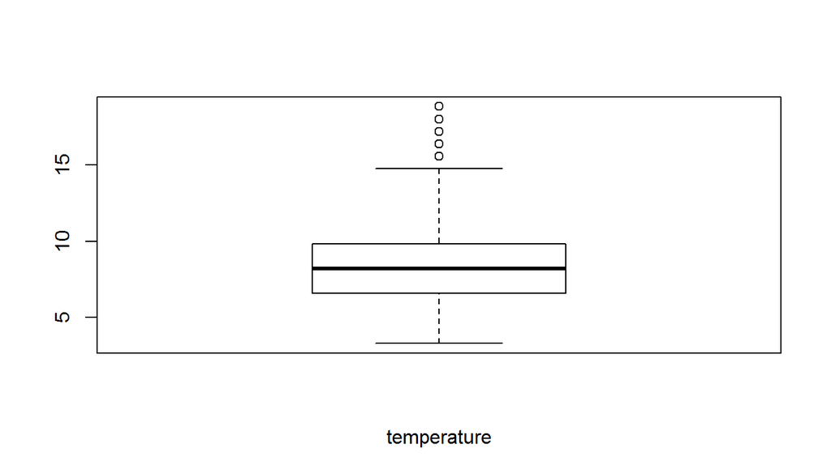

```r
boxplot(bikejan$temp,xlab="temperature")
```

```r
quantile(bikejan$temp,c(x/1000,0.05,0.1,0.2,0.25,0.3,0.4,0.5,0.6,0.7,0.75,0.8,0.9,0.95,0.96,0.97,0.98,0.99,y/1000))
```

```
##   0.1%   0.2%   0.3%   0.4%   0.5%   0.6%   0.7%   0.8%   0.9%     1%
##  3.280  3.280  3.280  3.280  3.505  3.879  4.100  4.100  4.100  4.100
##     5%    10%    20%    25%    30%    40%    50%    60%    70%    75%
##  4.920  5.740  6.560  6.560  6.560  7.380  8.200  8.200  9.020  9.840
##    80%    90%    95%    96%    97%    98%    99%    99%  99.1%  99.2%
##  9.840 13.120 16.400 16.400 17.220 17.958 18.860 18.860 18.860 18.860
##  99.3%  99.4%  99.5%  99.6%  99.7%  99.8%  99.9%
## 18.860 18.860 18.860 18.860 18.860 18.860 18.860
```

2. atemp

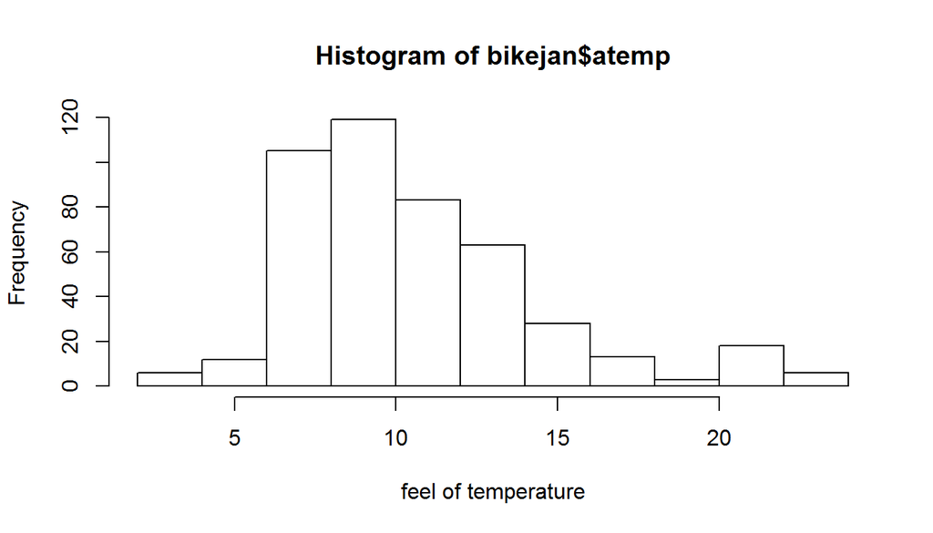

```r
hist(bikejan$atemp,xlab="feel of temperature")
```

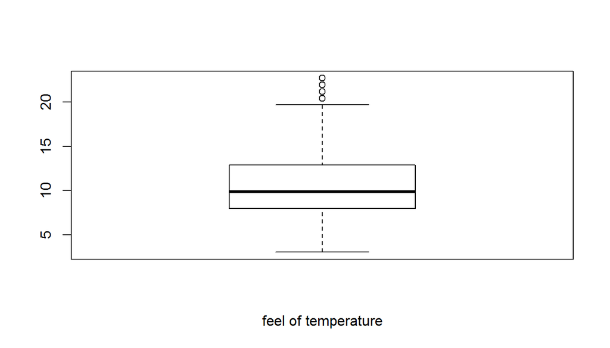

```r
boxplot(bikejan$atemp,xlab="feel of temperature")
```

```r
quantile(bikejan$atemp,c(x/1000,0.05,0.1,0.2,0.25,0.3,0.4,0.5,0.6,0.7,0.75,0.8,0.9,0.95,0.96,0.97,0.98,0.99,y/1000))
```

```
##   0.1%   0.2%   0.3%   0.4%   0.5%   0.6%   0.7%   0.8%   0.9%     1%
##  3.030  3.030  3.030  3.030  3.239  3.585  3.790  3.790  3.790  3.790
##     5%    10%    20%    25%    30%    40%    50%    60%    70%    75%
##  6.060  6.060  7.575  7.955  8.335  9.090  9.850 10.605 11.365 12.880
##    80%    90%    95%    96%    97%    98%    99%    99%  99.1%  99.2%
## 12.880 15.150 20.455 20.455 21.210 21.892 22.725 22.725 22.725 22.725
##  99.3%  99.4%  99.5%  99.6%  99.7%  99.8%  99.9%
## 22.725 22.725 22.725 22.725 22.725 22.725 22.725
```

3. humidity

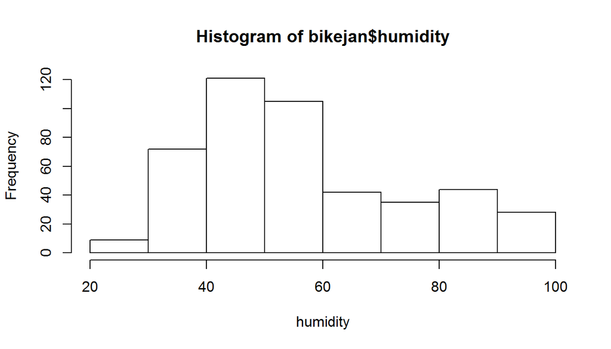

```r
hist(bikejan$humidity,xlab="humidity")
```

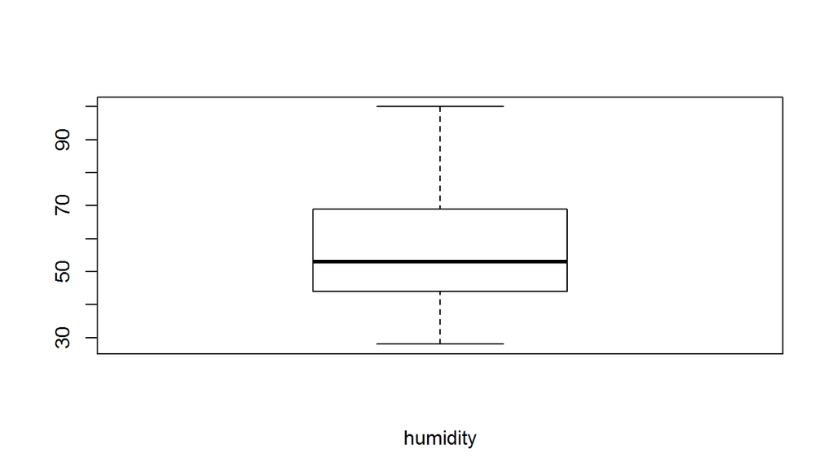

```r
boxplot(bikejan$humidity,xlab="humidity")
```

```r
quantile(bikejan$humidity,c(x/1000,0.05,0.1,0.2,0.25,0.3,0.4,0.5,0.6,0.7,0.75,0.8,0.9,0.95,0.96,0.97,0.98,0.99,y/1000))
```

```
##  0.1%  0.2%  0.3%  0.4%  0.5%  0.6%  0.7%  0.8%  0.9%    1%    5%   10%
## 28.00 28.00 28.00 28.00 28.28 28.73 29.18 29.64 30.00 30.00 35.00 38.00
##   20%   25%   30%   40%   50%   60%   70%   75%   80%   90%   95%   96%
## 43.00 44.00 47.00 50.00 53.00 56.00 64.00 69.00 75.00 86.00 93.00 93.00
##   97%   98%   99%   99% 99.1% 99.2% 99.3% 99.4% 99.5% 99.6% 99.7% 99.8%
## 93.00 93.00 93.45 93.45 93.90 94.00 94.00 94.00 94.00 94.00 94.00 94.54
## 99.9%
## 97.27
```

4. Wind Speed

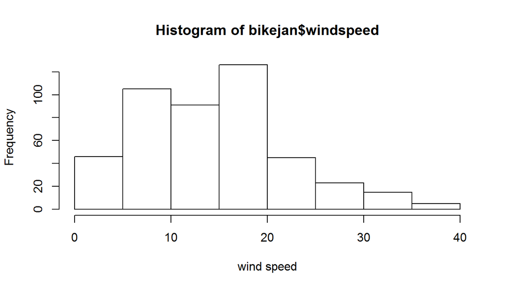

```r
hist(bikejan$windspeed,xlab="wind speed")
```

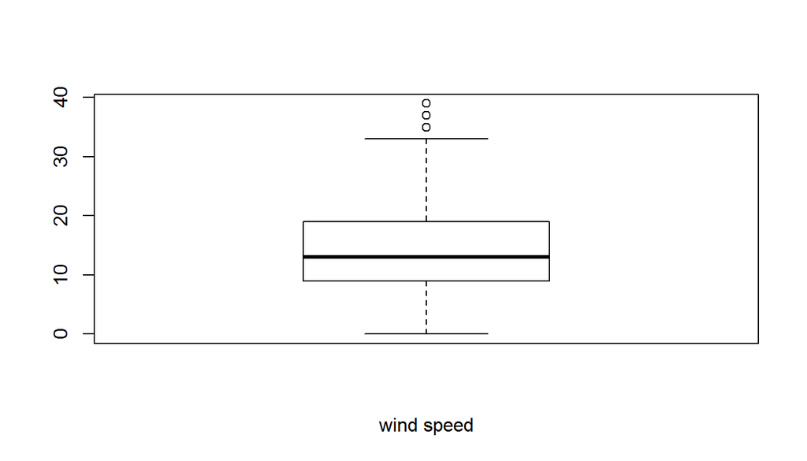

```r
boxplot(bikejan$windspeed,xlab="wind speed")
```

```r
quantile(bikejan$windspeed,c(x/1000,0.05,0.1,0.2,0.25,0.3,0.4,0.5,0.6,0.7,0.75,0.8,0.9,0.95,0.96,0.97,0.98,0.99,y/1000))
```

```
##   0.1%   0.2%   0.3%   0.4%   0.5%   0.6%   0.7%   0.8%   0.9%     1%
##  0.000  0.000  0.000  0.000  0.000  0.000  0.000  0.000  0.000  0.000
##     5%    10%    20%    25%    30%    40%    50%    60%    70%    75%
##  0.000  4.502  7.002  8.998  8.998 11.001 12.998 15.001 19.001 19.001
##    80%    90%    95%    96%    97%    98%    99%    99%  99.1%  99.2%
## 20.000 23.999 27.999 30.003 30.003 30.901 33.899 33.899 34.810 35.001
##  99.3%  99.4%  99.5%  99.6%  99.7%  99.8%  99.9%
## 35.001 35.001 35.001 35.360 36.269 37.178 38.089
```

5. Count

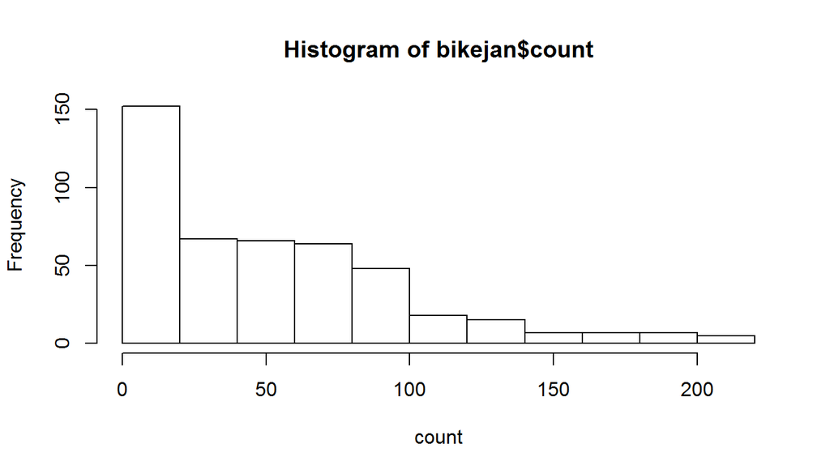

```r
hist(bikejan$count,xlab="count")
```

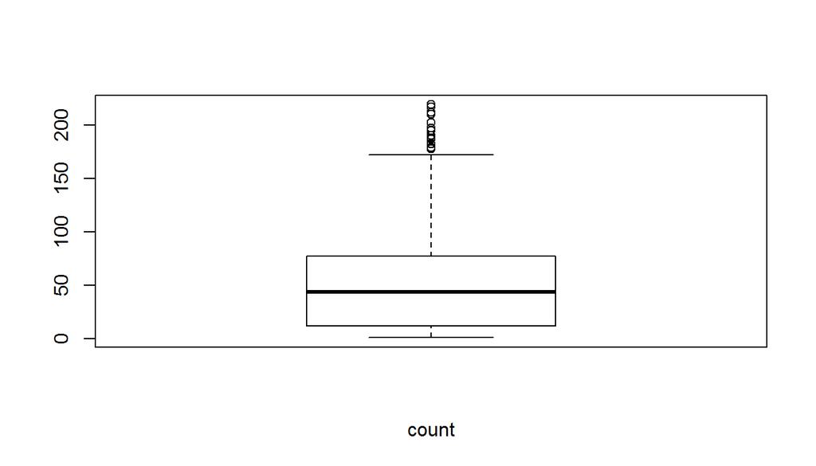

```r
boxplot(bikejan$count,xlab="count")
```

```r
quantile(bikejan$count,c(x/1000,0.05,0.1,0.2,0.25,0.3,0.4,0.5,0.6,0.7,0.75,0.8,0.9,0.95,0.96,0.97,0.98,0.99,y/1000))
```

```
##   0.1%   0.2%   0.3%   0.4%   0.5%   0.6%   0.7%   0.8%   0.9%     1%
##   1.00   1.00   1.00   1.00   1.00   1.00   1.00   1.00   1.00   1.00
##     5%    10%    20%    25%    30%    40%    50%    60%    70%    75%
##   1.00   3.00   6.00  12.00  17.00  32.00  44.00  57.00  71.00  77.25
##    80%    90%    95%    96%    97%    98%    99%    99%  99.1%  99.2%
##  86.00 114.00 155.50 160.60 174.10 187.90 199.25 199.25 201.52 204.88
##  99.3%  99.4%  99.5%  99.6%  99.7%  99.8%  99.9%
## 208.52 210.54 211.45 212.90 215.17 217.18 218.09
```

## Bivariate Analysis with categorical variables

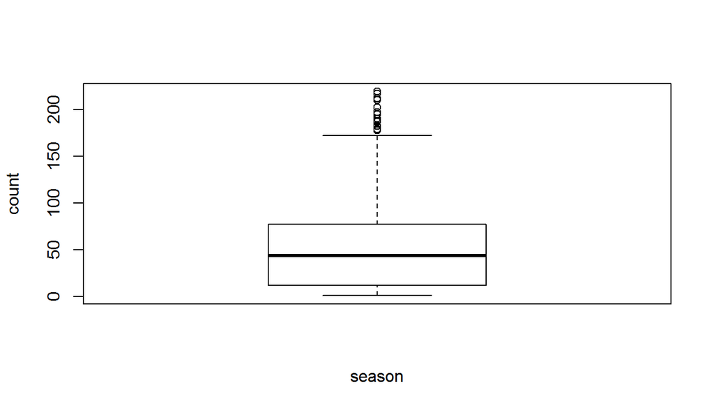

```r
boxplot(count~season,bikejan,xlab="season",ylab="count")
```

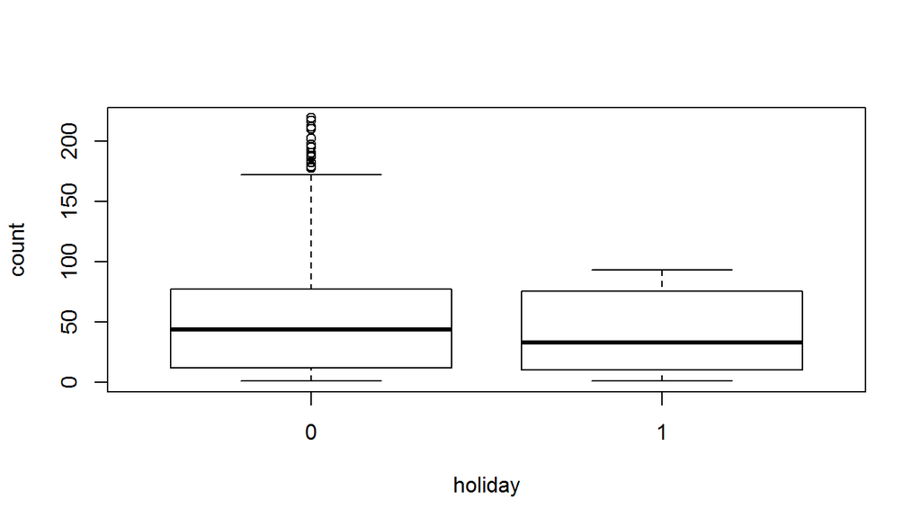

```r
boxplot(count~holiday,bikejan,xlab="holiday",ylab="count")
```

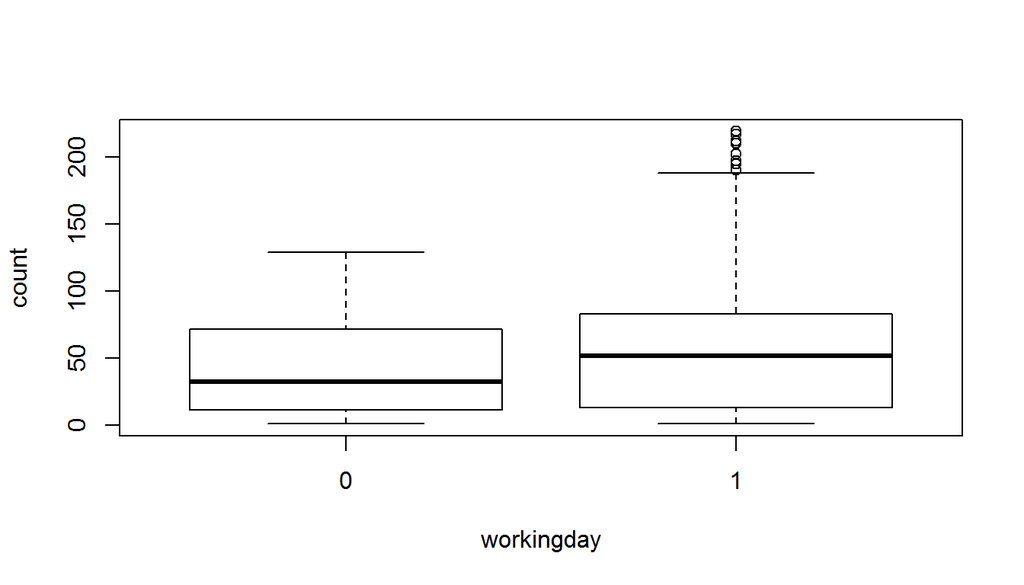

```r
boxplot(count~workingday,bikejan,xlab="workingday",ylab="count")
```

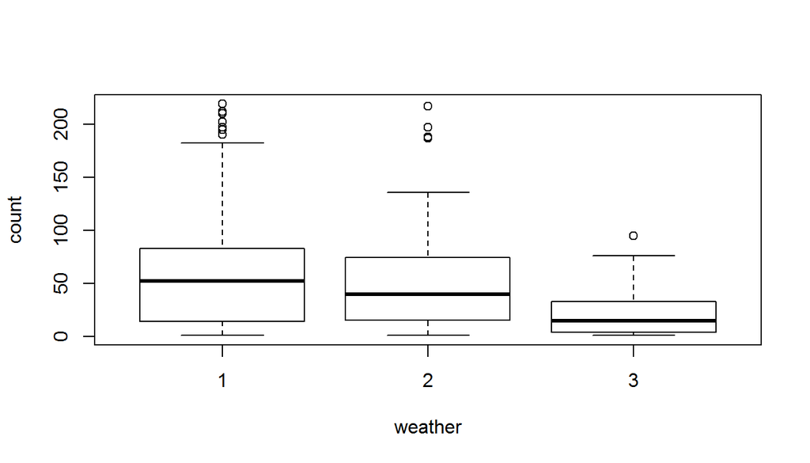

```r
boxplot(count~weather,bikejan,xlab="weather",ylab="count")
```

## Bivariate Analysis with continuous variables

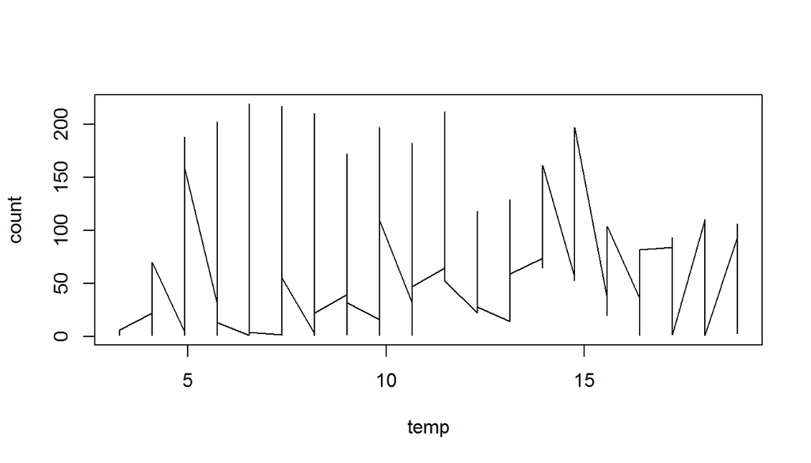

```r
plot(count~temp,bikejan[order(bikejan$temp),],type="l",xlab="temp",ylab="count")
```

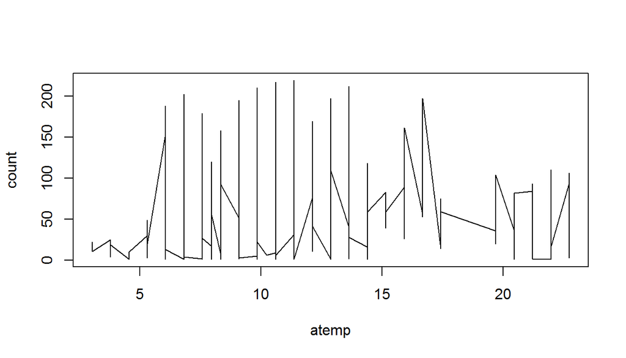

```r
plot(count~atemp,bikejan[order(bikejan$atemp),],type="l",xlab="atemp",ylab="count")
```

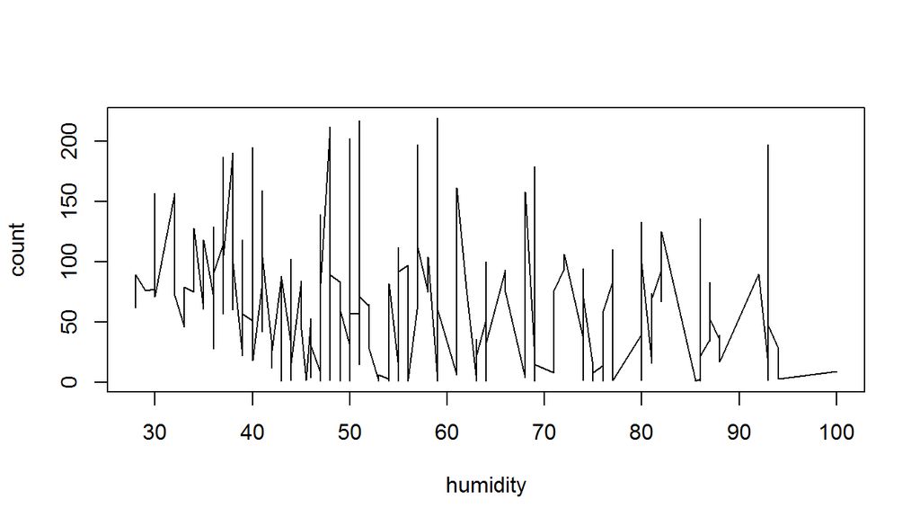

```r
plot(count~humidity,bikejan[order(bikejan$humidity),],type="l",xlab="humidity",ylab="count")
```

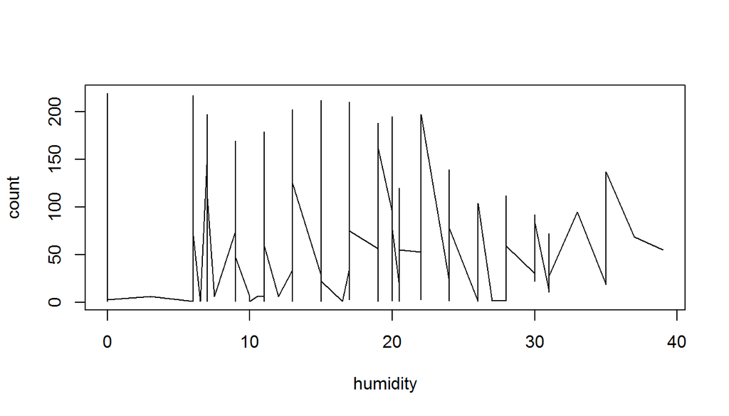

```r
plot(count~windspeed,bikejan[order(bikejan$windspeed),],type="l",xlab="humidity",ylab="count")
```

Time series Analysis

1. Hour

```r
bikejan_hour <- aggregate(count~hour,bikejan,sum)
head(bikejan_hour[order(-bikejan_hour$count),],4)
```

```
##    hour count
## 18   17  2536
## 9     8  2282
## 19   18  2192
## 17   16  1618
```

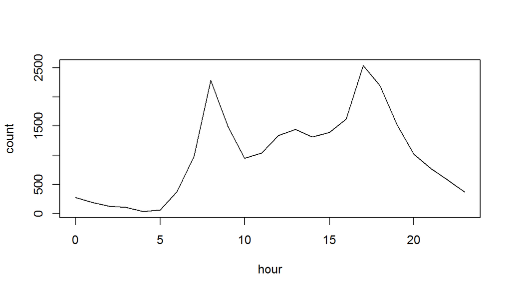

```r
plot(count~hour,bikejan_hour,type="l")
```

2. Day

```r
bikejan_day <- aggregate(count~day,bikejan,mean)
bikejan_day[order(-bikejan_day$count),]
```

```
##   day count
## 4   4 68.08
## 6   6 62.58
## 1   1 58.54
## 7   7 49.36
## 3   3 47.19
## 5   5 47.18
## 2   2 40.81
```

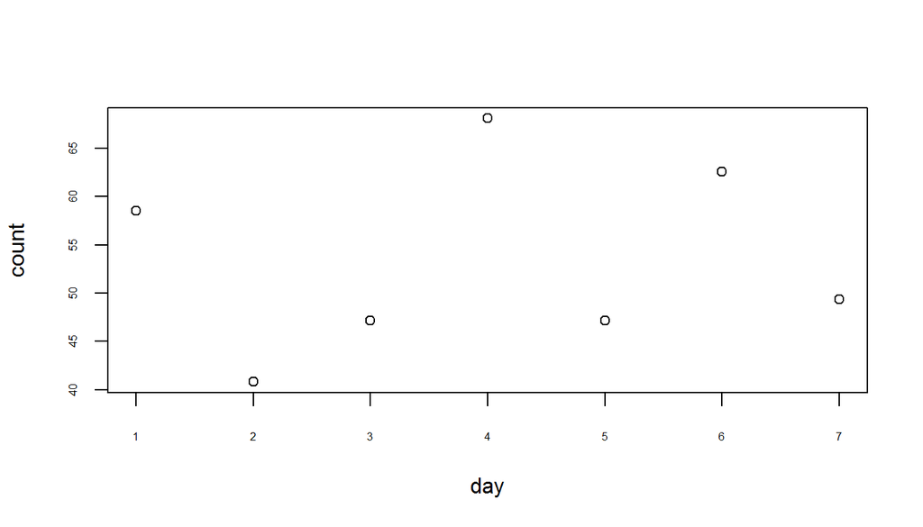

```r
plot(count~day,bikejan_day,cex.axis=0.50)
```

3. Date

```r
bikejan_date <- aggregate(count~date,bikejan,sum)
head(bikejan_date[order(-bikejan_date$count),])
```

```
##    date count
## 19   19  1656
## 6     6  1612
## 5     5  1606
## 4     4  1568
## 7     7  1516
## 14   14  1422
```

```r
tail(bikejan_date[order(-bikejan_date$count),])
```

```
##    date count
## 18   18  1105
## 17   17  1000
## 1     1   985
## 8     8   959
## 9     9   822
## 2     2   802
```

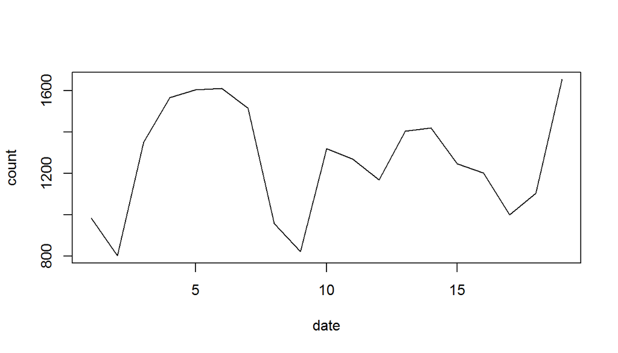

```r
plot(count~date,bikejan_date,type="l")
```